# Geographic Data Transformation, Storage, and Publication

# Introduction

Handling geographic data efficiently involves multiple steps: transforming it to match analysis requirements, storing it in optimized spatial databases, and publishing it for sharing or integration with other systems. This package offers a comprehensive solution to streamline the transformation, storage, and publication of raster and vector geographic data.

Built upon the powerful `sf` and `terra` R packages, this toolkit bridges the gap between local geographic data processing and server-based geographic information platforms like PostGIS and GeoServer. The primary aim is to simplify workflows for users dealing with diverse geographic data needs, allowing seamless transformation and integration of data processing, storage, and publication in R.

In this document, the datasets included in the package, as well as other datasets used within it, are presented first. Next, a section is dedicated to each group of functions: transformation, storage, and publication; each section illustrates the functions with examples. The document concludes by summarizing the functionalities and highlighting their advantages.

# Datasets

The package includes and uses the following datasets to support the workflows.

## `sigugr.gpkg`

```r
library(sigugr)

sigugr_gpkg <- system.file("extdata", "sigugr.gpkg", package = "sigugr")

sf::st_layers(sigugr_gpkg)
```

```
#> Driver: GPKG
#> Available layers:
#>   layer_name     geometry_type features fields              crs_name
#> 1      block           Polygon      104      1 ETRS89 / UTM zone 30N
#> 2        poi             Point      121      4 ETRS89 / UTM zone 30N
#> 3      hydro Multi Line String       11      4 ETRS89 / UTM zone 30N
#> 4   lanjaron     Multi Polygon        1      4 ETRS89 / UTM zone 30N
```

- `lanjaron`: A polygonal vector layer representing the boundaries of the municipality of Lanjarón, located in Granada, Spain. This data was sourced from the [*DERA (Datos Espaciales de Referencia de Andalucía)*](https://www.juntadeandalucia.es/institutodeestadisticaycartografia/dega/datos-espaciales-de-referencia-de-andalucia-dera).
- `hydro`: A multilines layer, also obtained from *DERA*, representing the hydrographic network for the municipality of Lanjarón.
- `poi`: A points layer representing points of interest, sourced from [*OpenStreetMap*](https://www.openstreetmap.org/) and clipped to the specified municipality.
- `block`: A polygon layer representing the building blocks of the considered municipality. The data was sourced from the [*CNIG (Centro Nacional de Información Geográfica)*](https://www.cnig.es/).

## `sat.tif`

```r
sat_tif <- system.file("extdata", "sat.tif", package = "sigugr")

sat <- terra::rast(sat_tif)

cat(paste("-", names(sat), collapse = "\n"))
```

```
#> - B2
#> - B3
#> - B4
#> - B5
#> - B6
#> - B7
```

Satellite bands for the Lanjarón area, downloaded from [*GloVis*](https://glovis.usgs.gov/app?fullscreen=0) (*USGS Global Visualization Viewer*) for *Landsat-8*. These bands were integrated and initially processed using the [`satres`](https://CRAN.R-project.org/package=satres) package. They have been resampled to a coarser resolution to be included in this package. These are the bands displayed as the result of the previous code snippet.

## `mdt`

```r
mdt_dir <- system.file("extdata", "mdt", package = "sigugr")

cat(paste("-", list.files(mdt_dir), collapse = "\n"))
```

```
#> - MDT25-ETRS89-H30-1026-4-COB2.TIF
#> - MDT25-ETRS89-H30-1027-3-COB2.TIF
#> - MDT25-ETRS89-H30-1041-2-COB2.TIF
#> - MDT25-ETRS89-H30-1041-4-COB2.TIF
#> - MDT25-ETRS89-H30-1042-1-COB2.TIF
#> - MDT25-ETRS89-H30-1042-3-COB2.TIF
```

A set of Digital Terrain Model (DTM) files corresponding to the sheets of the *National Topographic Map* of Spain for the Lanjarón area, obtained from the *CNIG*. These files have also been resampled to a coarser resolution to reduce storage requirements.

## `clc.gpkg`

```r
clc_gpkg <- system.file("extdata", "clc.gpkg", package = "clc")

sf::st_layers(clc_gpkg)
```

```
#> Driver: GPKG
#> Available layers:
#>     layer_name geometry_type features fields              crs_name
#> 1          clc Multi Polygon      136      2 ETRS89 / UTM zone 30N
#> 2     lanjaron Multi Polygon        1      4 ETRS89 / UTM zone 30N
#> 3 layer_styles            NA        1     12                  <NA>
```

This GeoPackage is included in the [`clc`](https://cran.r-project.org/package=clc) package. We will use the `clc` layer: a fragment of CLC data for the Lanjarón area, stored in vector format. This layer includes the associated style definitions, which are embedded within the same GeoPackage (`layer_styles` table.). The data was sourced from the *CNIG*.

# Data Transformation

This module provides tools for preparing and manipulating raster and vector data to meet specific requirements. It includes the following functions, that can be grouped into two categories: clipping and other transformations.

- Clipping:
  - `generate_bbox()`: Creates a bounding box as an `sf` object.
  - `clip_raster()`: Clips raster layers based on polygon geometries.
  - `clip_layer()`: Clips a vector layer using a polygon mask.
  - `clip_multipoligon()`: Clips multipolygon vector layers with safeguards against common errors.
- Other transformations:
  - `aggregate_rasters()`: Aggregates multiple raster files within a folder.
  - `compose_raster()`: Composes a single raster layer from multiple raster files.

## Other transformations

We have the set of files that comprise the DTM of the area. The resolution has already been modified once, and we will change it again as shown below.

```r
temp_dir <- tempdir()

result_files <- aggregate_rasters(mdt_dir, temp_dir, factor = 6)
```

The resulting files will be merged into a raster, which is also displayed below.

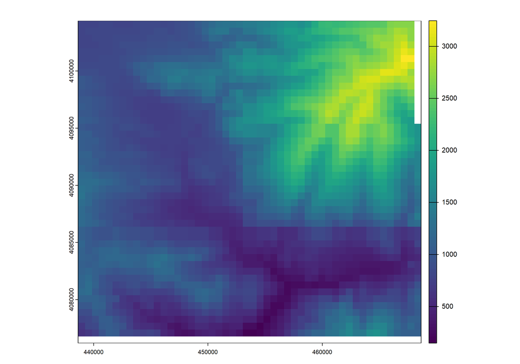

The aggregated and composed raster.

```r
r_mdt <- compose_raster(temp_dir)

terra::plot(r_mdt)
```

We will continue working with the DTM stored in the package, once it has been composed. When displayed in the following section, the difference in resolution compared to the previous image will be noticeable.

```r
mdt <- compose_raster(mdt_dir)
```

## Clipping

One common operation we frequently perform is clipping various layers using a polygon. However, in some cases, we clip them using the minimum enclosing bounding box instead. The function `generate_bbox()` can be used to obtain this bounding box.

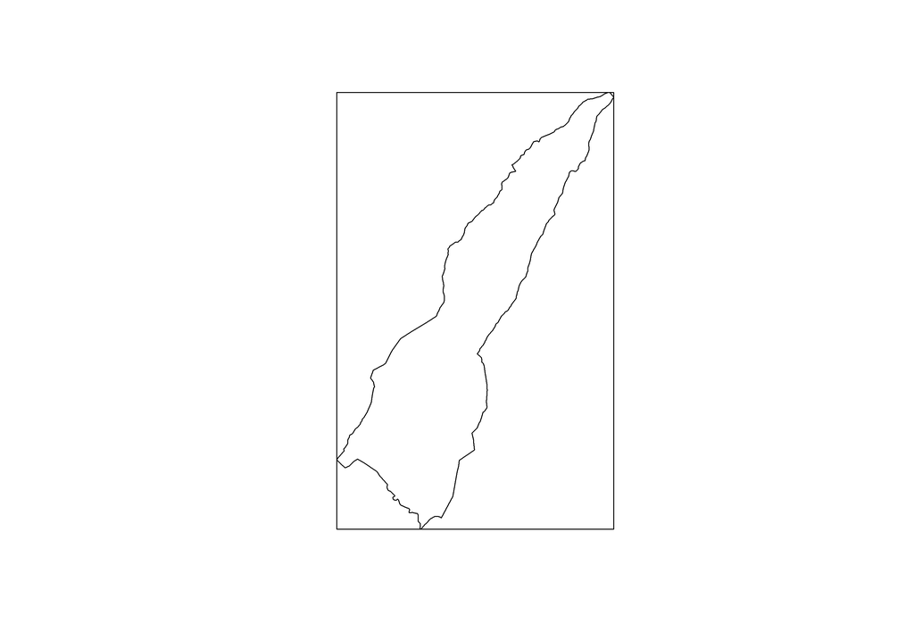

Polygon and bounding box.

```r
polygon <- sf::st_read(sigugr_gpkg, layer = "lanjaron", quiet = TRUE)

bbox <- generate_bbox(polygon)

plot(sf::st_geometry(bbox))
plot(sf::st_geometry(polygon), add = TRUE)
```

We will crop the DTM using the bounding box and then display the result.

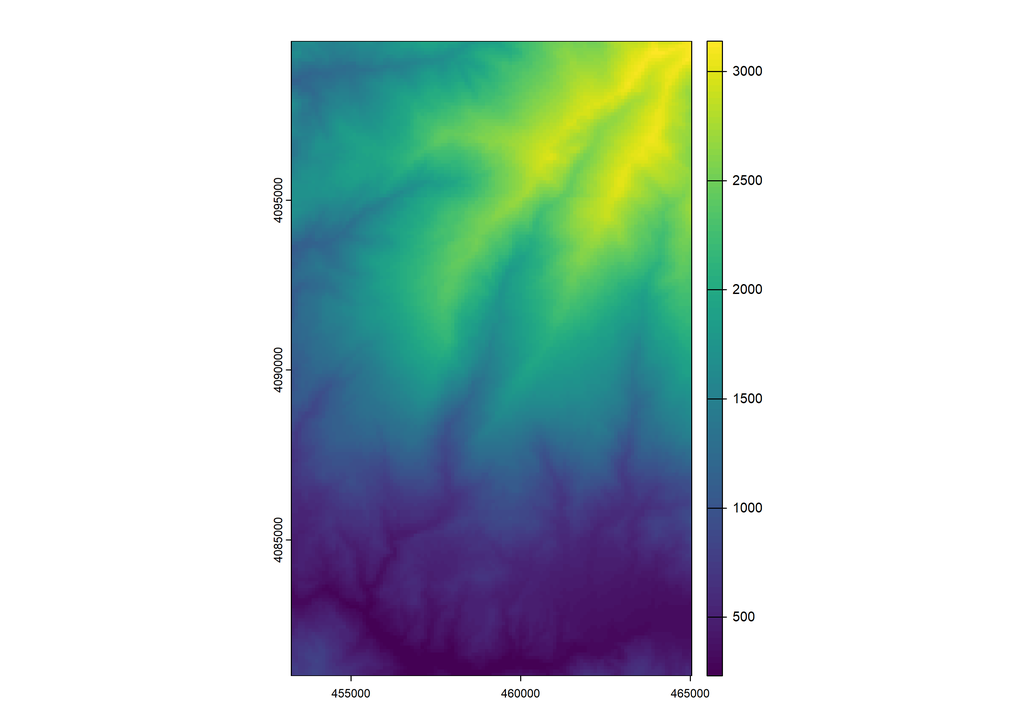

Clipped DTM.

```r
mdt_bbox <- clip_raster(mdt, bbox, keep_crs = FALSE)

terra::plot(mdt_bbox)
```

In this case, both layers share the same CRS, but the `keep_crs` parameter allows us to specify whether the resulting raster retains the CRS of the original raster or is reprojected to the CRS of the clipping polygon.

If it becomes necessary to change the raster’s CRS, an algorithm is applied to minimize the area being reprojected and to prevent distortions in the result.

To clip a vector layer, we will use the `clc` layer as shown below. The `clip_layer()` function produces a layer with the CRS of the clipping polygon.

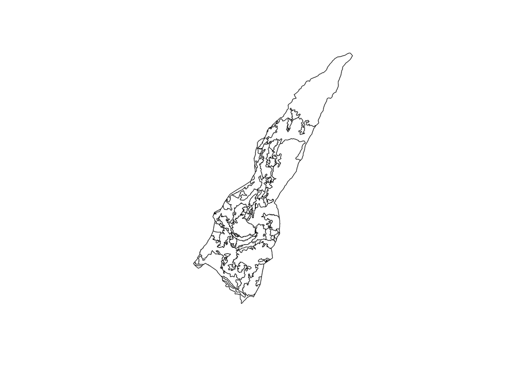

Clipped CLC layer.

```r
clc <- sf::st_read(clc_gpkg, layer = "clc", quiet = TRUE)

clc_polygon <- clip_layer(clc, polygon)

plot(sf::st_geometry(clc_polygon))
```

Clipping functions sometimes encounter issues with multipolygon geometries; these have been addressed with the `clip_multipolygon()` function, which performs the same operation as `clip_layer()` but uses more computationally expensive operations to mitigate the aforementioned issues.

To store in databases or publish the layers, they must be saved as files. Therefore, we will save the generated layers for later use.

```r
mdt_tif <- tempfile(fileext = ".tif")
terra::writeRaster(mdt_bbox, mdt_tif, overwrite = TRUE)

clc2_gpkg <- tempfile(fileext = ".gpkg")
sf::st_write(clc_polygon, clc2_gpkg, layer = "clc_polygon", delete_dsn = TRUE, quiet = TRUE)
```

# Data Storage in PostGIS

This module facilitates the storage of geographic data in a PostGIS database, offering optimized tools for handling both raster and vector data. The functions can be divided into two categories: layer storage and style management. The functions included are as follows:

- Layer storage:
  - `store_layers()`: Stores vector layers with geometries from GeoPackage or `sf` objects to PostGIS.
  - `store_raster()`: Stores raster datasets to PostGIS.
  - `store_bands()`: Stores individual raster bands in PostGIS for advanced analysis.
- Style management:
  - `copy_styles()`: Copies styles between layers in GeoPackages and PostGIS.
  - `get_layer_categories()`: Extracts style layer categories.

**Important Note:** The code from the examples in this section and the next was executed during the development of this document. However, it has been disabled afterward to avoid dependencies on the PostGIS database or the GeoServer, which are installed locally on my computer.

```r
evaluate <- FALSE
```

## Layer storage

Below, we store the following data into a PostGIS database:

- The original satellite bands: `store_bands()` stores each band in a separate table. Since the transformed bands had already been stored in the README document, a prefix is added to these.
- The generated DTM is stored using the `store_raster()` function, which writes all bands to the same table. However, the DTM consists of a single band.
- All layers from the original GeoPackage and the newly generated CLC layer, using the `store_layers()` function.

```r
conn <- DBI::dbConnect(
  RPostgres::Postgres(),
  dbname = "sigugr",
  host = "localhost",
  user = "postgres",
  password = "postgres"
)

tables1 <- store_bands(sat_tif, conn, prefix = 'original_')

tables2 <- store_raster(mdt_tif, conn, table_name = 'mdt')

tables3 <- store_layers(sigugr_gpkg, conn)

tables4 <- store_layers(clc2_gpkg, conn)
```

## Style management

The `clc_polygon` layer stored in the `clc2_gpkg` file has been copied to the database. However, the style of the original layer has not been transferred. We can copy the style using the `copy_styles()` function, as demonstrated below.

```r
copy_styles(from = clc_gpkg, to = conn, database = "sigugr", to_layers = "clc_polygon")
```

The result, including the layers available in the database and the `clc_polygon` layer with its styles, can be viewed in QGIS, as shown in the following figure.

[figure not shown]

Accessing PostGIS from QGIS.

Additionally, the `get_layer_categories()` function can be used to retrieve the definitions for each style code. This result can be applied to display raster bands derived from vector layers using the same style as the original layers.

# Data Publication on GeoServer

This module focuses on publishing geographic data to GeoServer. It is built around the `geoserver` class defined in the package, with its functions implemented as methods of this class.

- `geoserver()`: Manages GeoServer connection objects using an S3 class.
- `register_datastore_postgis()`: Registers PostGIS databases as GeoServer datastores.
- `publish_layer()`: Publishes vector layers to GeoServer.
- `publish_layer_set()`: Publishes a set of vector layers to GeoServer.
- `publish_raster()`: Publishes raster datasets to GeoServer.
- `publish_bands()`: Publishes individual raster bands as separate layers in GeoServer.

The following demonstrates how to publish all vector layers from the database. First, the `geoserver()` function is used to create an object with the connection parameters and workspace. Next, the PostGIS database is registered as a datastore using the `register_datastore_postgis()` function. Finally, vector layers can be published individually with the `publish_layer()` function or in bulk using the `publish_layer_set()` function, which connects to the database to retrieve the available vector layer names.

```r
gso <- geoserver(
  url = "http://localhost:8080/geoserver",
  user = "admin",
  password = "geoserver",
  workspace = "sigugr"
)

gso <- gso |>
  register_datastore_postgis(
    "sigugr-db",
    db_name = 'sigugr',
    host = 'localhost',
    port = 5432,
    db_user = 'postgres',
    db_password = 'postgres',
    schema = "public"
  )

gso |>
  publish_layer_set(conn)
```

On the other hand, rasters stored in files can also be published, as GeoServer does not support using PostGIS as a datastore for rasters. For rasters, it is possible to differentiate between publishing the entire raster with all bands together using the `publish_raster()` function or publishing each band individually using `publish_bands()`. In the latter case, a prefix is also added to distinguish these bands from those already published in the README document example.

```r
gso |>
  publish_raster(mdt_tif, layer = 'mdt')

gso |>
  publish_bands(sat_tif, prefix = 'original_')
```

As with PostGIS, GeoServer can be accessed via QGIS using WMS. The following figure shows the layers available on the server within the workspace defined in the connection, along with a display of one of the layers -specifically, the DTM generated earlier in this example.

[figure not shown]

Accessing GeoServer from QGIS.

# Conclusions

This package provides a framework for geographic data management, covering the lifecycle of data from processing to publication. The package enables users to:

- Seamlessly transform raster and vector datasets to suit various analytical and cartographic needs.
- Store geographic data persistently in PostGIS for efficient querying and analysis.
- Publish geographic data to GeoServer for visualization, sharing, and integration with web GIS systems.

The package is suitable for researchers, data analysts, and GIS professionals, facilitating robust workflows that bridge local data processing and server-based geospatial systems.